# Final Exam

Ziwen Zhang

December 13, 2022

# Question 1 (20 points)

## Question 1a

**Answer:** Variable 1 has a stronger relationship with cholesterol levels since the two tests have p-values < 0.05, thus, there are evidences to reject the null hypothesis and there is an association between variable1 and the cholesterol levels, and an association between variable2 and the cholesterol levels. In addition, the correlation coefficient of variable 1 is closer to -1 compared with the variable 2 to the 1, indicating that the relationship between variable 1 and cholesterol levle is stronger than that of variable 2.

## Question 1b

```r
(-0.67)^2
```

```
## [1] 0.4489
```

44.89% of the variation in the cholesterol levels can be explained by knowing the value of variable 1, because R^2 is (-0.67)^2 = 0.4489.

**Answer:** 44.89% of the variation in the cholesterol levels can be explained by knowing the value of variable 1, because R^2 is (-0.67)^2 = 0.4489.

## Question 1c

H0: There was no association between two variables and cholesterol levels H1: There is an association between two variables and cholesterol levels

the p-value is the probability of obtaining test results at least as extreme as the result actually observed, under the null-hypothesis.

## Question 1d

Cholesterol1 and Cholesterol 2 are positively related because Cholesterol 2 = Cholesterol 1 * 38.67 and the correlation coefficient should be 1.

## Question 1e

The correlation coefficients between Cholesterol2 and variable1 and variable2 will also be -0.67 and 0.42 respectively.

# Question 2 (16 points)

## Question 2a

H0: The means of daily calcium intake in three bone density groups are the same. H1: At least one mean of daily calcium intake among three bone density groups is different.

## Question 2b

```r
bMS1 <- 171.65
wMS1 <- 45.05

Fstat1 <- bMS1/wMS1
Fstat1
```

```
## [1] 3.810211
```

```r
bMS2 <- 150.35
wMS2 <- 54.67

Fstat2 <- bMS2/wMS2
Fstat2
```

```
## [1] 2.750137
```

The value of F-stat for WCM is 3.81 and the value of F-stat for Columbia is 2.75

## Question 2c

F statistics ~ Fk-1,n-1 distribution and in this case, the F3-1,150-3 distribution (F2,147 distribution).

## Question 2d

```r
k <- 3
n <- 150

pvalue1 <- 1 - pf(Fstat1, k - 1, n - k)
pvalue1
```

```
## [1] 0.02436186
```

```r
pvalue2 <- 1 - pf(Fstat2, k - 1, n - k)
pvalue2
```

```
## [1] 0.06720989
```

WCM’s dataset yields a smaller p-value. Because the F statistics for WCM is larger due to the fact that the between mean sq of WCM is larger and within mean sq of WCM is smaller and thus yields a larger F statistics.

## Question 2e

QQplot can be used to check normality, and Residual Analysis can be used to check equal variance. If the normality assumption can not be fulfilled, the Kruskal-Wallis test should be used. If the equal variance assumption can not be fulfilled (and normality is fulfilled), Welch test / oneway.test should be used.

# Question 3 (20 points)

```r
captopril <- read.csv("captopril.csv")
```

## Question 3a

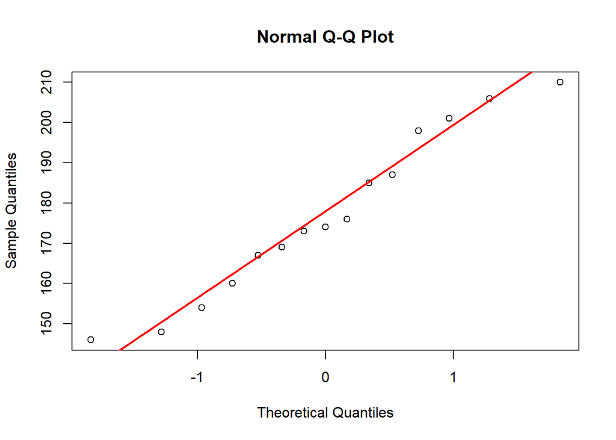

```r
qqnorm(captopril$bSBP)
qqline(captopril$bSBP, col = "red", lwd = 2)
```

Wilcoxon signed-rank test is appropriate since the sample size is relatively small and it is hard for us to conclude that this data follows a normal distribution (thus we need an non-parametric test). In addition, the data were obtained from the same patients, indicating that they are paired with each other, thus we do not use Wilcoxon rank-sum test.

## Question 3b

```r
wilcox.test(captopril$bSBP, captopril$aSBP, alternative = "two.sided",
    paired = TRUE)
```

```
##
##  Wilcoxon signed rank test with continuity correction
##
## data:  captopril$bSBP and captopril$aSBP
## V = 120, p-value = 0.0007211
## alternative hypothesis: true location shift is not equal to 0
```

Since the p-value is < 0.05, there is an evidence to reject the null hypothesis and thus there is a difference in SBP after the drug was administered compared to before.

## Question 3c

```r
fit <- lm(bSBP ~ bDBP, data = captopril)
summary(fit)
```

```
##
## Call:
## lm(formula = bSBP ~ bDBP, data = captopril)
##
## Residuals:
##     Min      1Q  Median      3Q     Max
## -21.971  -8.456  -5.164  13.849  29.335
##
## Coefficients:
##             Estimate Std. Error t value Pr(>|t|)
## (Intercept)  30.2854    45.8915   0.660  0.52082
## bDBP          1.3055     0.4069   3.208  0.00685 **
## ---
## Signif. codes:  0 '***' 0.001 '**' 0.01 '*' 0.05 '.' 0.1 ' ' 1
##
## Residual standard error: 15.94 on 13 degrees of freedom
## Multiple R-squared:  0.4419, Adjusted R-squared:  0.399
## F-statistic: 10.29 on 1 and 13 DF,  p-value: 0.006855
```

```r
confint(fit, "bDBP", level = 0.9) %>%
    round(4)
```

```
##         5 %  95 %
## bDBP 0.5849 2.026
```

The point estimate for the average change in baseline SBP for a one unit change in baseline DBP is 1.3055. The corresponding 90% CI is from 0.5849 to 2.026.

## Question 3d

```r
predict(fit, newdata = data.frame(bDBP = 110), interval = "prediction",
    conf.level = 0.95)
```

```
##        fit      lwr      upr
## 1 173.8872 138.2558 209.5187
```

# Question 4 (10 points)

## Question 4a

```r
1 - pbinom(6, size = 90, prob = 0.1)
```

```
## [1] 0.8075081
```

At least 90 patients should be enrolled to the study

## Question 4b

```r
power.t.test(n = NULL, delta = 10, sd = 15, sig.level = 0.05,
    power = 0.9, type = "two.sample", alternative = "two.sided")
```

```
##
##      Two-sample t test power calculation
##
##               n = 48.26431
##           delta = 10
##              sd = 15
##       sig.level = 0.05
##           power = 0.9
##     alternative = two.sided
##
## NOTE: n is number in *each* group
```

at least 49 participantes are needed in each group

# Question 5 (14 points)

```r
snoring <- read.csv("snoring.csv")
```

## Question 5a

H0: There is no association between snoring and the heart disease H1: There is an association between snoring and the heart disease

## Question 5b

```r
row1 <- c(1355, 603, 192, 214)
row2 <- c(24, 34, 21, 30)
data.matrix <- rbind(row1, row2)
rownames(data.matrix) <- c("no", "yes")
colnames(data.matrix) <- c("0", "1", "2", "3")
data.matrix
```

```
##        0   1   2   3
## no  1355 603 192 214
## yes   24  34  21  30
```

```r
chisq.results <- chisq.test(data.matrix, correct = FALSE)
chisq.results
```

```
##
##  Pearson's Chi-squared test
##
## data:  data.matrix
## X-squared = 75.643, df = 3, p-value = 2.637e-16
```

```r
chisq.results$expected
```

```
##              0         1          2         3
## no  1318.21917 608.92357 203.611808 233.24545
## yes   60.78083  28.07643   9.388192  10.75455
```

the expected number of participants who would have heart disease if they snore nearly every night is 10.75455

## Question 5c

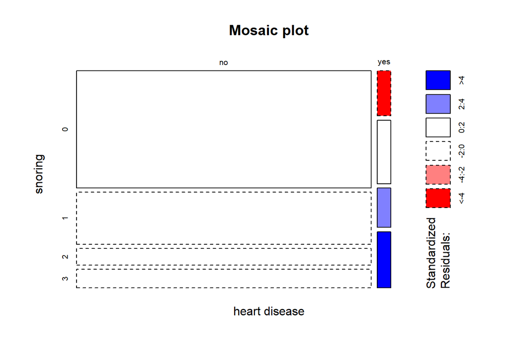

```r
mosaicplot(data.matrix, shade = TRUE, main = "Mosaic plot", ylab = "snoring",
    xlab = "heart disease")
```

It seems that both the 0 snoring group and 3 snoring group have the the greatest standardized difference between observed and expected numbers of individuals with heart disease.

## Question 5d

```r
FWER <- 1 - (1 - 0.05)^6
FWER
```

```
## [1] 0.2649081
```

The family-wise error rate for 6 comparisons when significance level is set at 0.05 for each individual comparison is 0.2649

# Question 6 (20 points)

## Question 6a

```r
a <- (1 - pnorm(30, 28, 6)) * 2
b <- (1 - pnorm(30, 27, 4)) * 2
c <- pnorm(30, 32, 2) * 2
d <- (1 - pnorm(30, 26, 9)) * 2
a
```

```
## [1] 0.7388827
```

```r
b
```

```
## [1] 0.4532547
```

```r
c
```

```
## [1] 0.3173105
```

```r
d
```

```
## [1] 0.6567213
```

3. because we will use t statistic to do this test and t = (x-30)/(s/sqrt(n)). In this case, n is a constant for each sample and when x is far away from 30 and s is small, the t statistic will be large. The corresponding p value will be small. This interpretation is consistent with the precise calculation.

## Question 6b

```r
pnorm(0.5, 0, 1) - pnorm(-0.5, 0, 1)
```

```
## [1] 0.3829249
```

the probability of observing a value within 0.5 standard deviations of the mean is 0.38

## Question 6c

```r
prop <- pnorm(75, 85, 12)
1 - pbinom(24, 40, prop)
```

```
## [1] 7.091956e-09
```

The probability of that in a class of 40 students, 25 or more finish in under 75 minutes is 7.091956e-09

## Question 6e

The second sample has a smaller confidence interval because A larger sample size will result in a narrower confidence interval.